# Make your Android application work on iOS – tutorial

Learn how to make your existing Android application cross-platform so that it works both on Android and iOS. You'll be able to write code and test it for both Android and iOS only once, in one place.

This tutorial uses a [sample Android application](https://github.com/Kotlin/kmm-integration-sample) with a single screen for entering a username and password. The credentials are validated and saved to an in-memory database.

## Prepare an environment for development

1. Install all the necessary tools and update them to the latest versions.
2. In Android Studio, create a new project from version control:

   ```
   https://github.com/Kotlin/kmm-integration-sample
   ```

3. Switch to the **Project** view.

[figure not shown]

## Make your code cross-platform

To make your application work on iOS, you'll first make your code cross-platform, and then you'll reuse your cross-platform code in a new iOS application.

To make your code cross-platform:

1. Decide what code to make cross-platform.
2. Create a shared module for cross-platform code.
3. Add a dependency on the shared module to your Android application.
4. Make the business logic cross-platform.
5. Run your cross-platform application on Android.

### Decide what code to make cross-platform

Decide which code of your Android application is better to share for iOS and which to keep native. A simple rule is: share what you want to reuse as much as possible. The business logic is often the same for both Android and iOS, so it's a great candidate for reuse.

In your sample Android application, the business logic is stored in the package `com.jetbrains.simplelogin.androidapp.data`. Your future iOS application will use the same logic, so you should make it cross-platform, as well.

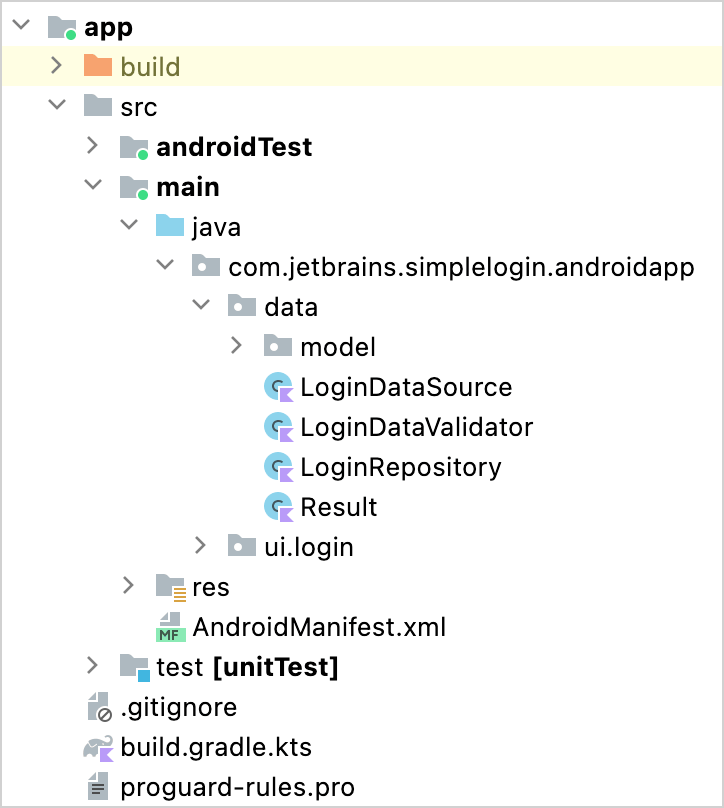

### Create a shared module for cross-platform code

The cross-platform code that is used for both iOS and Android *is stored* in the shared module. The Kotlin Multiplatform plugin provides a special wizard for creating such modules.

In your Android project, create a Kotlin Multiplatform shared module for your cross-platform code. Later you'll connect it to your existing Android application and your future iOS application.

1. In Android Studio, click **File** | **New** | **New Module**.
2. In the list of templates, select **Kotlin Multiplatform Shared Module**, enter the module name `shared`, and select the **Regular framework** in the list of iOS framework distribution options.  
   This is required for connecting the shared module to the iOS application.

[figure not shown]

3. Click **Finish**.

The wizard will create the Kotlin Multiplatform shared module, update the configuration files, and create files with classes that demonstrate the benefits of Kotlin Multiplatform. You can learn more about the project structure.

### Add a dependency on the shared module to your Android application

To use cross-platform code in your Android application, connect the shared module to it, move the business logic code there, and make this code cross-platform.

1. In the `build.gradle.kts` file of the shared module, ensure that `compileSdk` and `minSdk` are the same as those in the `build.gradle.kts` of your Android application in the `app` module.

   If they're different, update them in the `build.gradle.kts` of the shared module. Otherwise, you'll encounter a compile error.
2. Add a dependency on the shared module to the `build.gradle.kts` of your Android application.

   ```
   dependencies {
       implementation (project(":shared"))
   }
   ```

3. Synchronize the Gradle files by clicking **Sync Now** in the notification.

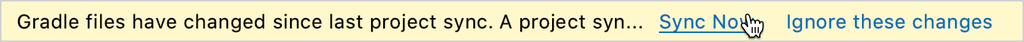

4. In the `app/src/main/java/` directory, open the `LoginActivity` class in the `com.jetbrains.simplelogin.androidapp.ui.login` package.
5. To make sure that the shared module is successfully connected to your application, dump the `greet()` function result to the log by updating the `onCreate()` method:

   ```
   override fun onCreate(savedInstanceState: Bundle?) {
       super.onCreate(savedInstanceState)

       Log.i("Login Activity", "Hello from shared module: " + (Greeting().greet()))
   }
   ```

6. Follow Android Studio suggestions to import missing classes.
7. Debug the `app`. On the **Logcat** tab, search for `Hello` in the log, and you'll find the greeting from the shared module.

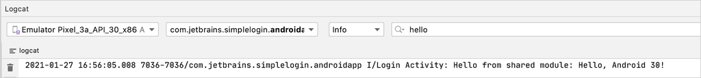

### Make the business logic cross-platform

You can now extract the business logic code to the Kotlin Multiplatform shared module and make it platform-independent. This is necessary for reusing the code for both Android and iOS.

1. Move the business logic code `com.jetbrains.simplelogin.androidapp.data` from the `app` directory to the `com.jetbrains.simplelogin.shared` package in the `shared/src/commonMain` directory. You can drag and drop the package or refactor it by moving everything from one directory to another.

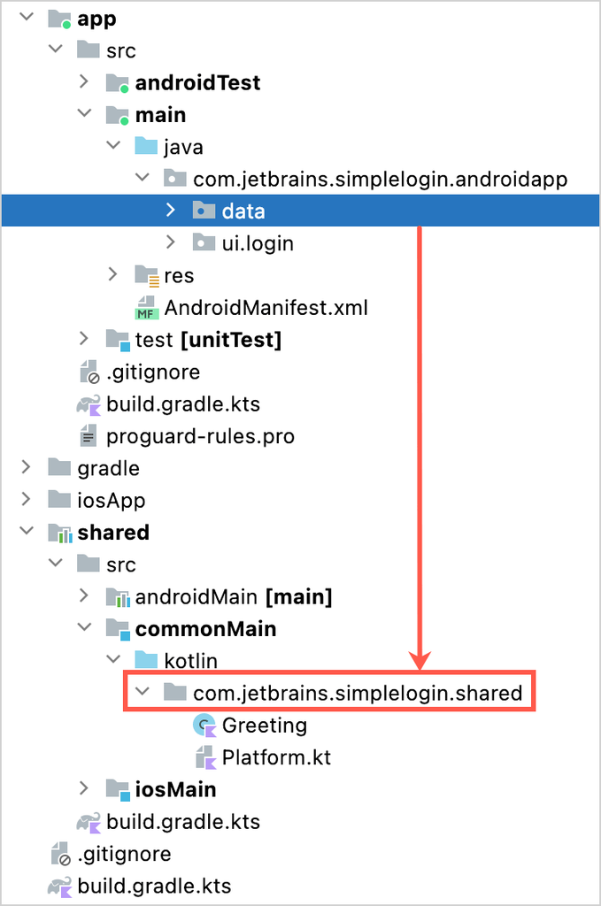

2. When Android Studio asks what you'd like to do, select to move the package, and then approve the refactoring.

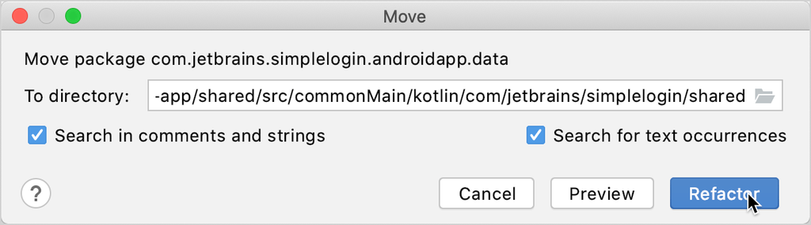

3. Ignore all warnings about platform-dependent code and click **Continue**.

[figure not shown]

4. Remove Android-specific code by replacing it with cross-platform Kotlin code or connecting to Android-specific APIs using `expect` and `actual` declarations. See the following sections for details:

#### Replace Android-specific code with cross-platform code

To make your code work well on both Android and iOS, replace all JVM dependencies with Kotlin dependencies in the moved `data` directory wherever possible.

1. In the `LoginDataSource` class, replace `IOException` in the `login()` function with `RuntimeException`. `IOException` is not available in Kotlin.

   ```
   // Before
   return Result.Error(IOException("Error logging in", e))
   ```

   ```
   // After
   return Result.Error(RuntimeException("Error logging in", e))
   ```

2. In the `LoginDataValidator` class, replace the `Patterns` class from the `android.utils` package with a Kotlin regular expression matching the pattern for email validation:

   ```
   // Before
   private fun isEmailValid(email: String) = Patterns.EMAIL_ADDRESS.matcher(email).matches()
   ```

   ```
   // After
   private fun isEmailValid(email: String) = emailRegex.matches(email)

   companion object {
       private val emailRegex =
           ("[a-zA-Z0-9\\+\\.\\_\\%\\-\\+]{1,256}" +
               "\\@" +
               "[a-zA-Z0-9][a-zA-Z0-9\\-]{0,64}" +
               "(" +
               "\\." +
               "[a-zA-Z0-9][a-zA-Z0-9\\-]{0,25}" +
               ")+").toRegex()
   }
   ```

#### Connect to platform-specific APIs from the cross-platform code

In the `LoginDataSource` class, a universally unique identifier (UUID) for `fakeUser` is generated using the `java.util.UUID` class, which is not available for iOS.

```
val fakeUser = LoggedInUser(java.util.UUID.randomUUID().toString(), "Jane Doe")
```

Since the Kotlin standard library doesn't provide functionality for generating UUIDs, you still need to use platform-specific functionality for this case.

Provide the `expect` declaration for the `randomUUID()` function in the shared code and its `actual` implementations for each platform – Android and iOS – in the corresponding source sets. You can learn more about connecting to platform-specific APIs.

1. Remove the `java.util.UUID` class from the common code:

   ```
   val fakeUser = LoggedInUser(randomUUID(), "Jane Doe")
   ```

2. Create the `Utils.kt` file in the `com.jetbrains.simplelogin.shared` package of the `shared/src/commonMain` directory and provide the `expect` declaration:

   ```
   package com.jetbrains.simplelogin.shared

   expect fun randomUUID(): String
   ```

3. Create the `Utils.kt` file in the `com.jetbrains.simplelogin.shared` package of the `shared/src/androidMain` directory and provide the `actual` implementation for `randomUUID()` in Android:

   ```
   package com.jetbrains.simplelogin.shared

   import java.util.*

   actual fun randomUUID() = UUID.randomUUID().toString()
   ```

4. Create the `Utils.kt` file in the `com.jetbrains.simplelogin.shared` of the `shared/src/iosMain` directory and provide the `actual` implementation for `randomUUID()` in iOS:

   ```
   package com.jetbrains.simplelogin.shared

   import platform.Foundation.NSUUID

   actual fun randomUUID(): String = NSUUID().UUIDString()
   ```

5. All it's left to do is to explicitly import `randomUUID` in the `LoginDataSource.kt` file of the `shared/src/commonMain` directory:

   ```
   import com.jetbrains.simplelogin.shared.randomUUID
   ```

   For Android and iOS, Kotlin will use its different platform-specific implementations.

### Run your cross-platform application on Android

Run your cross-platform application for Android to make sure it works.

[figure not shown]

## Make your cross-platform application work on iOS

Once you've made your Android application cross-platform, you can create an iOS application and reuse the shared business logic in it.

1. Create an iOS project in Xcode.
2. Connect the framework to your iOS project.
3. Use the shared module from Swift.

### Create an iOS project in Xcode

1. In Xcode, click **File** | **New** | **Project**.
2. Select a template for an iOS app and click **Next**.

[figure not shown]

3. As the product name, specify **simpleLoginIOS** and click **Next**.

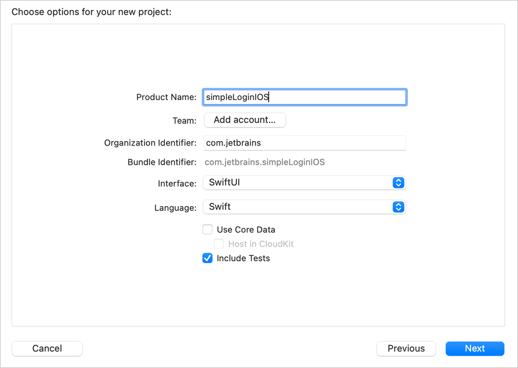

4. As the location for your project, select the directory that stores your cross-platform application, for example, `kmm-integration-sample`.

In Android Studio, you'll get the following structure:

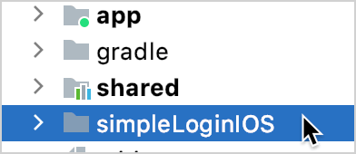

You can rename the `simpleLoginIOS` directory to `iosApp` for consistency with other top-level directories of your cross-platform project.

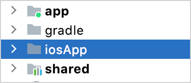

### Connect the framework to your iOS project

Once you have the framework, you can connect it to your iOS project manually.

Connect your framework to the iOS project manually:

1. In Xcode, open the iOS project settings by double-clicking the project name.
2. On the **Build Phases** tab of the project settings, click the **+** and add **New Run Script Phase**.

[figure not shown]

3. Add the following script:

   ```
   cd "$SRCROOT/.."
   ./gradlew :shared:embedAndSignAppleFrameworkForXcode
   ```

[figure not shown]

4. Move the **Run Script** phase before the **Compile Sources** phase.

[figure not shown]

5. On the **Build Settings** tab, switch to **All** build settings and specify the **Framework Search Path** under **Search Paths**:

   ```
   $(SRCROOT)/../shared/build/xcode-frameworks/$(CONFIGURATION)/$(SDK_NAME)
   ```

[figure not shown]

6. On the **Build Settings** tab, specify the **Other Linker flags** under **Linking**:

   ```
   $(inherited) -framework shared
   ```

[figure not shown]

7. Build the project in Xcode. If everything is set up correctly, the project will successfully build.

### Use the shared module from Swift

1. In Xcode, open the `ContentView.swift` file and import the `shared` module:

   ```
   import shared
   ```

2. To check that it is properly connected, use the `greet()` function from the shared module of your cross-platform app:

   ```
   import SwiftUI
   import shared

   struct ContentView: View {
       var body: some View {
           Text(Greeting().greet())
           .padding()
       }
   }
   ```

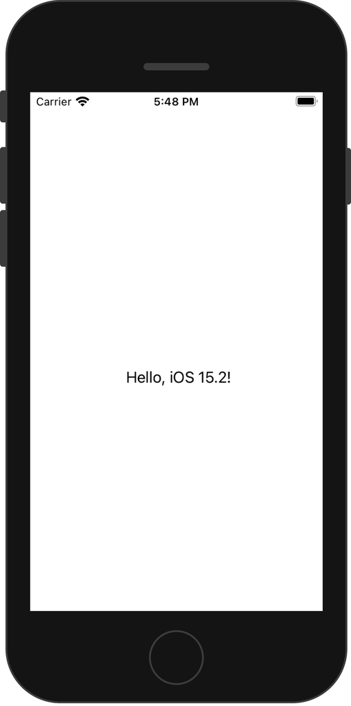

   ```
   import SwiftUI
   import shared

   @main
   struct SimpleLoginIOSApp: App {
       var body: some Scene {
           WindowGroup {
               ContentView(viewModel: .init(loginRepository: LoginRepository(dataSource: LoginDataSource()), loginValidator: LoginDataValidator()))
           }
       }
   }
   ```

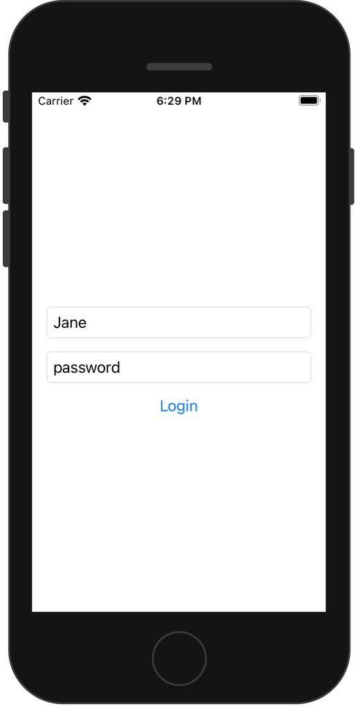

## Enjoy the results – update the logic only once

Now your application is cross-platform. You can update the business logic in one place and see results on both Android and iOS.

1. In Android Studio, change the validation logic for a user's password in the `checkPassword()` function of the `LoginDataValidator` class:

   ```
   package com.jetbrains.simplelogin.shared.data

   class LoginDataValidator {
   //...
       fun checkPassword(password: String): Result {
           return when {
               password.length < 5 -> Result.Error("Password must be >5 characters")
               password.lowercase() == "password" -> Result.Error("Password shouldn't be \"password\"")
               else -> Result.Success
           }
       }
   //...
   }
   ```

2. Run both the iOS and Android applications from Android Studio to see the changes:

[figure not shown]

[figure not shown]

You can review the [final code for this tutorial](https://github.com/Kotlin/kmm-integration-sample/tree/final).

## What else to share?

You've shared the business logic of your application, but you can also decide to share other layers of your application. For example, the `ViewModel` class code is almost the same for [Android](https://github.com/Kotlin/kmm-integration-sample/blob/final/app/src/main/java/com/jetbrains/simplelogin/androidapp/ui/login/LoginViewModel.kt) and [iOS applications](https://github.com/Kotlin/kmm-integration-sample/blob/final/iosApp/SimpleLoginIOS/ContentView.swift#L84), and you can share it if your mobile applications should have the same presentation layer.

## What's next?

Once you've made your Android application cross-platform, you can move on and:

- Add dependencies on multiplatform libraries
- Add Android dependencies
- Add iOS dependencies

You can also check out community resources:

- [Video: 3 ways to get your Kotlin JVM code ready for Kotlin Multiplatform Mobile](https://www.youtube.com/watch?v=X6ckI1JWjqo)

Last modified: 11 May 2023